# Module 205

#### Hemi-module gene counts:

300 probesets in hemi-module A.  
32 probesets in hemi-module B.  
Note: While the mapping of probesets to genes is usually one-to-one, some genes are targeted by multiple probesets, some probesets target multiple genes, and some probesets do not target any genes (i.e., the region of the genome they match is no longer considered genic).

#### Contrast SVE:

Signed variance explained (SVE) provides an indication of how similar a set of fold changes are to a gene module’s weight vector. An SVE value of 0.3, for example, indicates that 30% of the variance explained by the entire module set is accounted for by the module in question. Shown here are the SVE values for this module across a compendium of fold changes (contrasts). Extreme SVE values (e.g., > 0.05) indicate that those contrasts specifically induce (orange dots) or specifically repress (blue dots) this module. Examining the experimental conditions being compared in such contrasts (see tables below the figure) may provide insight into the gene module’s function.

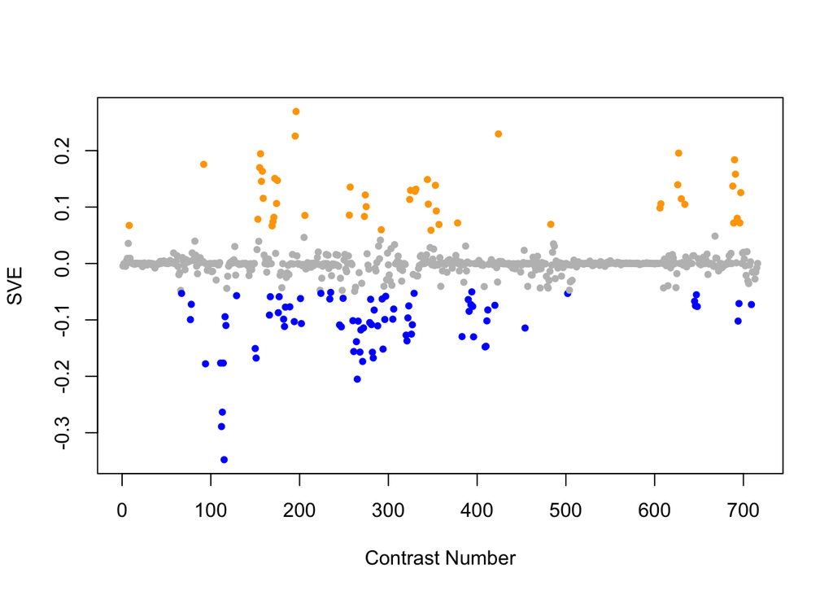

Positive SVE Contrasts:

|  | Contrast.Num | SVE | GEO.GSE | Cond.1 | Cond.2 | Mutation |
| --- | --- | --- | --- | --- | --- | --- |
| GSE43959.s1t1.vs.s3t1 | 196 | 0.27 | GSE43959 | N2 young adult on E. coli OP50 rep 1 | N2 young adult on Comamonas DA1877 rep 1 |  |
| GSE27867.s1t1.vs.s0t1 | 424 | 0.23 | GSE27867 | tag-24, biological rep1 | wt, biological rep1 | tag-24 |
| GSE43959.s2t1.vs.s3t1 | 195 | 0.23 | GSE43959 | N2 young adult on E. coli HT115 rep 1 | N2 young adult on Comamonas DA1877 rep 1 |  |
| GSE19310A.s5t1.vs.s0t1 | 627 | 0.20 | GSE19310 | dpy-9(e12) at iso, rep1 | N2 at iso, rep1 | dpy-9 |
| GSE47778.s5t1.vs.s2t1 | 156 | 0.19 | GSE47778 | xpa-1 0mJ/cm2; replicate 1 | daf-2; replicate 1 | xpa-1 vs. daf-2 |
| GSE11055.s1t6.vs.s2t6 | 690 | 0.18 | GSE11055 | L1 larvae 12 hr after hatching in the presence of food | L1 larvae 12 hr after hatching in the absence of food |  |
| GSE5801.s2t1.vs.s1t1 | 92 | 0.18 | GSE5801 | daf2daf16_RepA | daf2_RepA | daf-16 |
| GSE47778.s1t1.vs.s2t1 | 155 | 0.17 | GSE47778 | N2; replicate 1 | daf-2; replicate 1 | daf-2 |
| GSE47778.s5t1.vs.s4t1 | 158 | 0.16 | GSE47778 | xpa-1 0mJ/cm2; replicate 1 | daf-2;daf-16; replicate 1 | xpa-1 vs. daf-2;daf-16 |
| GSE11055.s4t7.vs.s2t7 | 691 | 0.16 | GSE11055 | L1 larvae fed for 12 hr after hatching and then starved for 3 hr | L1 larvae 15 hr after hatching in the absence of food |  |
| GSE47778.s5t3.vs.s2t3 | 172 | 0.15 | GSE47778 | xpa-1 10mJ/cm2; replicate 1 | daf-2; UV; replicate 1 | xpa-1 vs. daf-2 |
| GSE38997.s1t3.vs.s1t1 | 344 | 0.15 | GSE38997 | experiment 1 control samples at 48 h 1c48 | experiment 4 control samples at 3 h 4c3 |  |
| GSE47778.s5t3.vs.s1t3 | 175 | 0.15 | GSE47778 | xpa-1 10mJ/cm2; replicate 1 | N2; UV; replicate 1 | xpa-1 |
| GSE47778.s1t1.vs.s4t1 | 157 | 0.15 | GSE47778 | N2; replicate 1 | daf-2;daf-16; replicate 1 | daf-2;daf-16 |
| GSE19310A.s4t1.vs.s0t1 | 626 | 0.14 | GSE19310 | dpy-10(e128) at iso, rep3 | N2 at iso, rep1 | dpy-10 |
| GSE38997.s4t3.vs.s4t1 | 353 | 0.14 | GSE38997 | experiment 1 UVC-exposed samples at 48 h 1u48 | experiment 4 UVC-exposed samples at 3 h 4u3 |  |
| GSE11055.s1t2.vs.s2t2 | 688 | 0.14 | GSE11055 | L1 larvae 0 hr after hatching in the presence of food | L1 larvae 0 hr after hatching in the absence of food |  |
| GSE41366A.s1t2.vs.s0t2 | 257 | 0.14 | GSE41366 | low_DDVP-2h_expose-14h_harvest-rep1 | control-2h_expose-14h_harvest-rep1 |  |
| GSE38997.s4t4.vs.s3t4 | 331 | 0.13 | GSE38997 | experiment 1 UVC-exposed samples at 51 h 1u51 | experiment 1 UVC- and EtBr-exposed samples at 51 h 1eu51 |  |
| GSE38997.s4t3.vs.s3t3 | 325 | 0.13 | GSE38997 | experiment 1 UVC-exposed samples at 48 h 1u48 | experiment 1 UVC- and EtBr-exposed samples at 48 h 1eu48 |  |
| GSE38997.s4t4.vs.s2t4 | 330 | 0.13 | GSE38997 | experiment 1 UVC-exposed samples at 51 h 1u51 | experiment 1 EtBr-exposed samples at 51 h 1e51 |  |
| GSE11055.s1t8.vs.s2t8 | 697 | 0.13 | GSE11055 | L2 larvae 24 hr after hatching in the presence of food | L1 larvae 24 hr after hatching in the absence of food |  |
| GSE41366B.s1t1.vs.s0t1 | 274 | 0.12 | GSE41366 | low_DDVP-8h_expose-14h_harvest-rep1 | control-8h_expose-14h_harvest-rep1 |  |
| GSE47778.s5t1.vs.s1t1 | 159 | 0.12 | GSE47778 | xpa-1 0mJ/cm2; replicate 1 | N2; replicate 1 | xpa-1 |
| GSE19310A.s3t1.vs.s0t1 | 630 | 0.11 | GSE19310 | osm-8(n1518) at iso, rep1 | N2 at iso, rep1 | osm-8 |
| GSE38997.s4t3.vs.s2t3 | 324 | 0.11 | GSE38997 | experiment 1 UVC-exposed samples at 48 h 1u48 | experiment 1 EtBr-exposed samples at 48 h 1e48 |  |
| GSE47778.s5t3.vs.s4t3 | 174 | 0.11 | GSE47778 | xpa-1 10mJ/cm2; replicate 1 | daf-2;daf-16; UV; replicate 1 | xpa-1 vs. daf-2;daf-16 |
| GSE21784.s1t1.vs.s2t1 | 607 | 0.11 | GSE21784 | L4 larvae, biological rep1 | day 6 adults, biological rep 1 |  |
| GSE38997.s1t4.vs.s1t1 | 345 | 0.11 | GSE38997 | experiment 1 control samples at 51 h 1c51 | experiment 4 control samples at 3 h 4c3 |  |
| GSE19138.s1t1.vs.s0t1 | 634 | 0.10 | GSE19138 | ALG-1(-) 1 | WT1 | alg-1 |
| GSE41366B.s2t2.vs.s0t2 | 275 | 0.10 | GSE41366 | high_DDVP-8h_expose-20h_harvest-rep1 | control-8h_expose-20h_harvest-rep1 |  |
| GSE21784.s1t1.vs.s3t1 | 606 | 0.10 | GSE21784 | L4 larvae, biological rep1 | day 15 adults, biological rep 1 |  |
| GSE38997.s4t4.vs.s4t1 | 354 | 0.09 | GSE38997 | experiment 1 UVC-exposed samples at 51 h 1u51 | experiment 4 UVC-exposed samples at 3 h 4u3 |  |
| GSE41366A.s2t2.vs.s0t2 | 256 | 0.09 | GSE41366 | high_DDVP-2h_expose-14h_harvest-rep1 | control-2h_expose-14h_harvest-rep1 |  |
| GSE42703.s2t2.vs.s1t2 | 206 | 0.09 | GSE42703 | WT incubated with H2O, biological rep1 | kgb-1 incubated with H2O, biological rep1 | kgb-1 |
| GSE41366B.s2t1.vs.s0t1 | 273 | 0.08 | GSE41366 | high_DDVP-8h_expose-14h_harvest-rep1 | control-8h_expose-14h_harvest-rep1 |  |
| GSE47778.s1t3.vs.s2t3 | 171 | 0.08 | GSE47778 | N2; UV; replicate 1 | daf-2; UV; replicate 1 | daf-2 |
| GSE11055.s1t7.vs.s2t7 | 693 | 0.08 | GSE11055 | L1-L2 larvae 15 hr after hatching in the presence of food | L1 larvae 15 hr after hatching in the absence of food |  |
| GSE47778.s5t1.vs.s3t1 | 153 | 0.08 | GSE47778 | xpa-1 0mJ/cm2; replicate 1 | daf-16; replicate 1 | xpa-1 vs. daf-16 |
| GSE47778.s4t3.vs.s2t3 | 170 | 0.07 | GSE47778 | daf-2;daf-16; UV; replicate 1 | daf-2; UV; replicate 1 | daf-2;daf-16 vs. daf-2 |
| GSE11055.s1t7.vs.s5t7 | 696 | 0.07 | GSE11055 | L1-L2 larvae 15 hr after hatching in the presence of food | L1 larvae starved for 12 hr after hatching and then fed for 3 hr |  |
| GSE35354B.s1t4.vs.s1t1 | 378 | 0.07 | GSE35354 | TA300_rep1 | TA Control_rep1 |  |
| GSE11055.s1t3.vs.s2t3 | 689 | 0.07 | GSE11055 | L1 larvae 1 hr after hatching in the presence of food | L1 larvae 1 hr after hatching in the absence of food |  |
| GSE23528A.s0t3.vs.s0t1 | 483 | 0.07 | GSE23528 | Adult at T10, non-entrained control time-series experiment 4 | Adult at T2, non-entrained control time-series experiment 4 |  |
| GSE38196.s1t2.vs.s0t2 | 357 | 0.07 | GSE38196 | atfs-1(tm4525)-treated, biological rep1 | wild-type-treated, biological rep1 | afts-1 |
| GSE9897B.s5t1.vs.s0t1 | 8 | 0.07 | GSE9897 | Complex I RNAi Mutant 5 | Wildtype (control for RNAi) | D2030.4 |
| GSE47778.s5t3.vs.s3t3 | 169 | 0.07 | GSE47778 | xpa-1 10mJ/cm2; replicate 1 | daf-16; UV; replicate 1 | xpa-1 vs. daf-16 |
| GSE41366C.s1t2.vs.s0t2 | 292 | 0.06 | GSE41366 | low_DDVP-continuous_expose-8h_harvest-rep1 | control-continuous_expose-2h_harvest-rep1 |  |
| GSE38997.s2t4.vs.s2t1 | 348 | 0.06 | GSE38997 | experiment 1 EtBr-exposed samples at 51 h 1e51 | experiment 4 EtBr-exposed samples at 3 h 4e3 |  |

Negative SVE Contrasts:

|  | Contrast.Num | SVE | GEO.GSE | Cond.1 | Cond.2 | Mutation |
| --- | --- | --- | --- | --- | --- | --- |
| GSE54024.s1t1.vs.s5t1 | 115 | -0.35 | GSE54024 | Wild type young adults, biological rep 1 | ced-4(n1162) young adults, biological rep 1 | ced-4 |
| GSE54024.s4t1.vs.s5t1 | 112 | -0.29 | GSE54024 | isp-1(qm150) young adults, biological rep 1 | ced-4(n1162) young adults, biological rep 1 |  |
| GSE54024.s3t1.vs.s5t1 | 113 | -0.26 | GSE54024 | nuo-6(qm200) young adults, biological rep 1 | ced-4(n1162) young adults, biological rep 1 |  |
| GSE41366A.s0t3.vs.s0t1 | 265 | -0.21 | GSE41366 | control-2h_expose-20h_harvest-rep1 | control-2h_expose-8h_harvest-rep1 |  |
| GSE5801.s3t1.vs.s2t1 | 94 | -0.18 | GSE5801 | daf2pmk1_RepA | daf2daf16_RepA |  |
| GSE54024.s2t1.vs.s5t1 | 114 | -0.18 | GSE54024 | Wild type young adults treated with 0.1mM paraquat, biological rep 1 | ced-4(n1162) young adults, biological rep 1 |  |
| GSE54024.s6t1.vs.s5t1 | 111 | -0.18 | GSE54024 | isp-1(qm150) ced-4(n1162) double mutant young adults, biological rep 1 | ced-4(n1162) young adults, biological rep 1 | isp-1 |
| GSE41366A.s1t3.vs.s1t1 | 271 | -0.17 | GSE41366 | low_DDVP-2h_expose-20h_harvest-rep1 | low_DDVP-2h_expose-8h_harvest-rep1 |  |
| GSE47778.s4t1.vs.s3t1 | 151 | -0.17 | GSE47778 | daf-2;daf-16; replicate 1 | daf-16; replicate 1 | daf-2;daf-16 vs. daf-16 |
| GSE41366B.s1t2.vs.s1t1 | 283 | -0.17 | GSE41366 | low_DDVP-8h_expose-20h_harvest-rep1 | low_DDVP-8h_expose-14h_harvest-rep1 |  |
| GSE41366B.s2t3.vs.s2t1 | 282 | -0.16 | GSE41366 | high_DDVP-8h_expose-26h_harvest-rep1 | high_DDVP-8h_expose-14h_harvest-rep1 |  |
| GSE41366A.s2t3.vs.s2t1 | 268 | -0.16 | GSE41366 | high_DDVP-2h_expose-20h_harvest-rep1 | high_DDVP-2h_expose-8h_harvest-rep1 |  |
| GSE41366A.s1t4.vs.s0t4 | 261 | -0.16 | GSE41366 | low_DDVP-2h_expose-26h_harvest-rep1 | control-2h_expose-26h_harvest-rep1 |  |
| GSE41366C.s1t3.vs.s0t3 | 294 | -0.15 | GSE41366 | low_DDVP-continuous_expose-14h_harvest-rep1 | control-continuous_expose-8h_harvest-rep1 |  |
| GSE47778.s2t1.vs.s3t1 | 150 | -0.15 | GSE47778 | daf-2; replicate 1 | daf-16; replicate 1 | daf-2 vs. daf-16 |
| GSE30505.s4t2.vs.s4t1 | 409 | -0.15 | GSE30505 | Day 8 glp-1 ash-2 #1 | L3 glp-1 ash-2 #1 |  |
| GSE30505.s3t2.vs.s3t1 | 410 | -0.15 | GSE30505 | Day 8 glp-1 E.V. #1 | L3 glp-1 E.V. #1 |  |
| GSE41366A.s0t2.vs.s0t1 | 264 | -0.14 | GSE41366 | control-2h_expose-14h_harvest-rep1 | control-2h_expose-8h_harvest-rep1 |  |
| GSE38997.s3t3.vs.s1t3 | 321 | -0.14 | GSE38997 | experiment 1 UVC- and EtBr-exposed samples at 48 h 1eu48 | experiment 1 control samples at 48 h 1c48 |  |
| GSE32031.s1t1.vs.s0t1 | 396 | -0.13 | GSE32031 | Exerimental (nhr-23 RNAi), biological rep1 | Control, biological rep1 | nhr-23 |
| GSE34113.s1t1.vs.s0t1 | 383 | -0.13 | GSE34113 | tdp-1(ok803) | wild-type 1 | tdp-1 |
| GSE38997.s2t3.vs.s1t3 | 320 | -0.13 | GSE38997 | experiment 1 EtBr-exposed samples at 48 h 1e48 | experiment 1 control samples at 48 h 1c48 |  |
| GSE38997.s2t4.vs.s1t4 | 326 | -0.13 | GSE38997 | experiment 1 EtBr-exposed samples at 51 h 1e51 | experiment 1 control samples at 51 h 1c51 |  |
| GSE41366A.s2t4.vs.s2t1 | 269 | -0.12 | GSE41366 | high_DDVP-2h_expose-26h_harvest-rep1 | high_DDVP-2h_expose-8h_harvest-rep1 |  |
| GSE25513.s2t1.vs.s0t1 | 454 | -0.11 | GSE25513 | crh-1 null (1) | WT (1) | crh-1 |
| GSE41366A.s1t4.vs.s1t1 | 272 | -0.11 | GSE41366 | low_DDVP-2h_expose-26h_harvest-rep1 | low_DDVP-2h_expose-8h_harvest-rep1 |  |
| GSE42592C.s2t3.vs.s2t2 | 247 | -0.11 | GSE42592 | mercury_mid_expose-8h_rep1 | mercury_mid_expose-4h_rep1 |  |
| GSE47778.s1t3.vs.s1t1 | 183 | -0.11 | GSE47778 | N2; UV; replicate 1 | N2; replicate 1 |  |
| GSE41366C.s1t4.vs.s0t4 | 288 | -0.11 | GSE41366 | low_DDVP-continuous_expose-20h_harvest-rep1 | control-continuous_expose-14h_harvest-rep1 |  |
| GSE54024.s3t1.vs.s6t1 | 117 | -0.11 | GSE54024 | nuo-6(qm200) young adults, biological rep 1 | isp-1(qm150) ced-4(n1162) double mutant young adults, biological rep 1 |  |

[output cut: 51 more lines]

$~$

#### Contrast SVE, Up-Regulated Genes Only:

Calculating SVE for up-regulated and down-regulated genes separately may be more informative in many cases than projecting the up- and down- gene sets together. This is due to the fact that the weight distribution of many modules is highly skewed, indicating that only one of the hemi-modules may be biologically meaningful (i.e., a set of genes are strongly correlated by only a few genes (or none) are strongly anti-correlated to that set.)

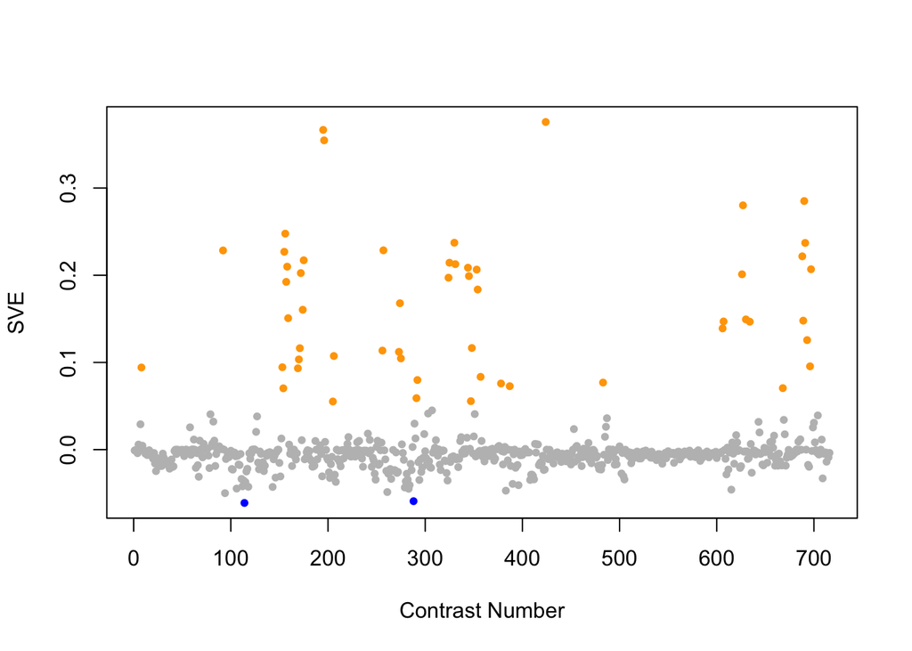

Positive SVE Contrasts:

|  | Contrast.Num | SVE | GEO.GSE | Cond.1 | Cond.2 | Mutation |
| --- | --- | --- | --- | --- | --- | --- |
| GSE27867.s1t1.vs.s0t1 | 424 | 0.38 | GSE27867 | tag-24, biological rep1 | wt, biological rep1 | tag-24 |
| GSE43959.s2t1.vs.s3t1 | 195 | 0.37 | GSE43959 | N2 young adult on E. coli HT115 rep 1 | N2 young adult on Comamonas DA1877 rep 1 |  |
| GSE43959.s1t1.vs.s3t1 | 196 | 0.35 | GSE43959 | N2 young adult on E. coli OP50 rep 1 | N2 young adult on Comamonas DA1877 rep 1 |  |
| GSE11055.s1t6.vs.s2t6 | 690 | 0.29 | GSE11055 | L1 larvae 12 hr after hatching in the presence of food | L1 larvae 12 hr after hatching in the absence of food |  |
| GSE19310A.s5t1.vs.s0t1 | 627 | 0.28 | GSE19310 | dpy-9(e12) at iso, rep1 | N2 at iso, rep1 | dpy-9 |
| GSE47778.s5t1.vs.s2t1 | 156 | 0.25 | GSE47778 | xpa-1 0mJ/cm2; replicate 1 | daf-2; replicate 1 | xpa-1 vs. daf-2 |
| GSE38997.s4t4.vs.s2t4 | 330 | 0.24 | GSE38997 | experiment 1 UVC-exposed samples at 51 h 1u51 | experiment 1 EtBr-exposed samples at 51 h 1e51 |  |
| GSE11055.s4t7.vs.s2t7 | 691 | 0.24 | GSE11055 | L1 larvae fed for 12 hr after hatching and then starved for 3 hr | L1 larvae 15 hr after hatching in the absence of food |  |
| GSE41366A.s1t2.vs.s0t2 | 257 | 0.23 | GSE41366 | low_DDVP-2h_expose-14h_harvest-rep1 | control-2h_expose-14h_harvest-rep1 |  |
| GSE5801.s2t1.vs.s1t1 | 92 | 0.23 | GSE5801 | daf2daf16_RepA | daf2_RepA | daf-16 |
| GSE47778.s1t1.vs.s2t1 | 155 | 0.23 | GSE47778 | N2; replicate 1 | daf-2; replicate 1 | daf-2 |
| GSE11055.s1t2.vs.s2t2 | 688 | 0.22 | GSE11055 | L1 larvae 0 hr after hatching in the presence of food | L1 larvae 0 hr after hatching in the absence of food |  |
| GSE47778.s5t3.vs.s1t3 | 175 | 0.22 | GSE47778 | xpa-1 10mJ/cm2; replicate 1 | N2; UV; replicate 1 | xpa-1 |
| GSE38997.s4t3.vs.s3t3 | 325 | 0.21 | GSE38997 | experiment 1 UVC-exposed samples at 48 h 1u48 | experiment 1 UVC- and EtBr-exposed samples at 48 h 1eu48 |  |
| GSE38997.s4t4.vs.s3t4 | 331 | 0.21 | GSE38997 | experiment 1 UVC-exposed samples at 51 h 1u51 | experiment 1 UVC- and EtBr-exposed samples at 51 h 1eu51 |  |
| GSE47778.s5t1.vs.s4t1 | 158 | 0.21 | GSE47778 | xpa-1 0mJ/cm2; replicate 1 | daf-2;daf-16; replicate 1 | xpa-1 vs. daf-2;daf-16 |
| GSE38997.s1t3.vs.s1t1 | 344 | 0.21 | GSE38997 | experiment 1 control samples at 48 h 1c48 | experiment 4 control samples at 3 h 4c3 |  |
| GSE11055.s1t8.vs.s2t8 | 697 | 0.21 | GSE11055 | L2 larvae 24 hr after hatching in the presence of food | L1 larvae 24 hr after hatching in the absence of food |  |
| GSE38997.s4t3.vs.s4t1 | 353 | 0.21 | GSE38997 | experiment 1 UVC-exposed samples at 48 h 1u48 | experiment 4 UVC-exposed samples at 3 h 4u3 |  |
| GSE47778.s5t3.vs.s2t3 | 172 | 0.20 | GSE47778 | xpa-1 10mJ/cm2; replicate 1 | daf-2; UV; replicate 1 | xpa-1 vs. daf-2 |
| GSE19310A.s4t1.vs.s0t1 | 626 | 0.20 | GSE19310 | dpy-10(e128) at iso, rep3 | N2 at iso, rep1 | dpy-10 |
| GSE38997.s1t4.vs.s1t1 | 345 | 0.20 | GSE38997 | experiment 1 control samples at 51 h 1c51 | experiment 4 control samples at 3 h 4c3 |  |
| GSE38997.s4t3.vs.s2t3 | 324 | 0.20 | GSE38997 | experiment 1 UVC-exposed samples at 48 h 1u48 | experiment 1 EtBr-exposed samples at 48 h 1e48 |  |
| GSE47778.s1t1.vs.s4t1 | 157 | 0.19 | GSE47778 | N2; replicate 1 | daf-2;daf-16; replicate 1 | daf-2;daf-16 |
| GSE38997.s4t4.vs.s4t1 | 354 | 0.18 | GSE38997 | experiment 1 UVC-exposed samples at 51 h 1u51 | experiment 4 UVC-exposed samples at 3 h 4u3 |  |
| GSE41366B.s1t1.vs.s0t1 | 274 | 0.17 | GSE41366 | low_DDVP-8h_expose-14h_harvest-rep1 | control-8h_expose-14h_harvest-rep1 |  |
| GSE47778.s5t3.vs.s4t3 | 174 | 0.16 | GSE47778 | xpa-1 10mJ/cm2; replicate 1 | daf-2;daf-16; UV; replicate 1 | xpa-1 vs. daf-2;daf-16 |
| GSE47778.s5t1.vs.s1t1 | 159 | 0.15 | GSE47778 | xpa-1 0mJ/cm2; replicate 1 | N2; replicate 1 | xpa-1 |
| GSE19310A.s3t1.vs.s0t1 | 630 | 0.15 | GSE19310 | osm-8(n1518) at iso, rep1 | N2 at iso, rep1 | osm-8 |
| GSE11055.s1t3.vs.s2t3 | 689 | 0.15 | GSE11055 | L1 larvae 1 hr after hatching in the presence of food | L1 larvae 1 hr after hatching in the absence of food |  |
| GSE21784.s1t1.vs.s2t1 | 607 | 0.15 | GSE21784 | L4 larvae, biological rep1 | day 6 adults, biological rep 1 |  |
| GSE19138.s1t1.vs.s0t1 | 634 | 0.15 | GSE19138 | ALG-1(-) 1 | WT1 | alg-1 |
| GSE21784.s1t1.vs.s3t1 | 606 | 0.14 | GSE21784 | L4 larvae, biological rep1 | day 15 adults, biological rep 1 |  |
| GSE11055.s1t7.vs.s2t7 | 693 | 0.13 | GSE11055 | L1-L2 larvae 15 hr after hatching in the presence of food | L1 larvae 15 hr after hatching in the absence of food |  |
| GSE38997.s2t4.vs.s2t1 | 348 | 0.12 | GSE38997 | experiment 1 EtBr-exposed samples at 51 h 1e51 | experiment 4 EtBr-exposed samples at 3 h 4e3 |  |
| GSE47778.s1t3.vs.s2t3 | 171 | 0.12 | GSE47778 | N2; UV; replicate 1 | daf-2; UV; replicate 1 | daf-2 |
| GSE41366A.s2t2.vs.s0t2 | 256 | 0.11 | GSE41366 | high_DDVP-2h_expose-14h_harvest-rep1 | control-2h_expose-14h_harvest-rep1 |  |
| GSE41366B.s2t1.vs.s0t1 | 273 | 0.11 | GSE41366 | high_DDVP-8h_expose-14h_harvest-rep1 | control-8h_expose-14h_harvest-rep1 |  |
| GSE42703.s2t2.vs.s1t2 | 206 | 0.11 | GSE42703 | WT incubated with H2O, biological rep1 | kgb-1 incubated with H2O, biological rep1 | kgb-1 |
| GSE41366B.s2t2.vs.s0t2 | 275 | 0.10 | GSE41366 | high_DDVP-8h_expose-20h_harvest-rep1 | control-8h_expose-20h_harvest-rep1 |  |
| GSE47778.s4t3.vs.s2t3 | 170 | 0.10 | GSE47778 | daf-2;daf-16; UV; replicate 1 | daf-2; UV; replicate 1 | daf-2;daf-16 vs. daf-2 |
| GSE11055.s1t7.vs.s5t7 | 696 | 0.10 | GSE11055 | L1-L2 larvae 15 hr after hatching in the presence of food | L1 larvae starved for 12 hr after hatching and then fed for 3 hr |  |
| GSE47778.s5t1.vs.s3t1 | 153 | 0.09 | GSE47778 | xpa-1 0mJ/cm2; replicate 1 | daf-16; replicate 1 | xpa-1 vs. daf-16 |
| GSE9897B.s5t1.vs.s0t1 | 8 | 0.09 | GSE9897 | Complex I RNAi Mutant 5 | Wildtype (control for RNAi) | D2030.4 |
| GSE47778.s5t3.vs.s3t3 | 169 | 0.09 | GSE47778 | xpa-1 10mJ/cm2; replicate 1 | daf-16; UV; replicate 1 | xpa-1 vs. daf-16 |
| GSE38196.s1t2.vs.s0t2 | 357 | 0.08 | GSE38196 | atfs-1(tm4525)-treated, biological rep1 | wild-type-treated, biological rep1 | afts-1 |
| GSE41366C.s1t2.vs.s0t2 | 292 | 0.08 | GSE41366 | low_DDVP-continuous_expose-8h_harvest-rep1 | control-continuous_expose-2h_harvest-rep1 |  |
| GSE23528A.s0t3.vs.s0t1 | 483 | 0.08 | GSE23528 | Adult at T10, non-entrained control time-series experiment 4 | Adult at T2, non-entrained control time-series experiment 4 |  |
| GSE35354B.s1t4.vs.s1t1 | 378 | 0.08 | GSE35354 | TA300_rep1 | TA Control_rep1 |  |
| GSE34026.s1t1.vs.s0t1 | 387 | 0.07 | GSE34026 | N2 exposed to hemolysin mutant of E7946, biological rep1 | N2 exposed to OP50(E.coli), biological rep1 |  |
| GSE15016.s4t1.vs.s0t1 | 668 | 0.07 | GSE15016 | young adult_24hr BPA exposure_rep1 | young adult_not exposured_rep1 |  |
| GSE47778.s4t1.vs.s2t1 | 154 | 0.07 | GSE47778 | daf-2;daf-16; replicate 1 | daf-2; replicate 1 | daf-2;daf-16 vs. daf-2 |
| GSE41366C.s2t2.vs.s0t2 | 291 | 0.06 | GSE41366 | high_DDVP-continuous_expose-8h_harvest-rep1 | control-continuous_expose-2h_harvest-rep1 |  |
| GSE38997.s2t3.vs.s2t1 | 347 | 0.06 | GSE38997 | experiment 1 EtBr-exposed samples at 48 h 1e48 | experiment 4 EtBr-exposed samples at 3 h 4e3 |  |
| GSE42703.s2t1.vs.s1t1 | 205 | 0.06 | GSE42703 | WT incubated with 1mM copper sulfate, biological rep1 | kgb-1 incubated with 1mM copper sulfate, biological rep1 | kgb-1 |

Negative SVE Contrasts:

|  | Contrast.Num | SVE | GEO.GSE | Cond.1 | Cond.2 | Mutation |
| --- | --- | --- | --- | --- | --- | --- |
| GSE54024.s2t1.vs.s5t1 | 114 | -0.06 | GSE54024 | Wild type young adults treated with 0.1mM paraquat, biological rep 1 | ced-4(n1162) young adults, biological rep 1 |  |
| GSE41366C.s1t4.vs.s0t4 | 288 | -0.06 | GSE41366 | low_DDVP-continuous_expose-20h_harvest-rep1 | control-continuous_expose-14h_harvest-rep1 |  |
| GSE5801.s3t1.vs.s2t1 | 94 | -0.05 | GSE5801 | daf2pmk1_RepA | daf2daf16_RepA |  |
| GSE41366A.s1t4.vs.s0t4 | 261 | -0.05 | GSE41366 | low_DDVP-2h_expose-26h_harvest-rep1 | control-2h_expose-26h_harvest-rep1 |  |
| GSE34113.s1t1.vs.s0t1 | 383 | -0.05 | GSE34113 | tdp-1(ok803) | wild-type 1 | tdp-1 |

$~$

#### Contrast SVE, Down-Regulated Genes Only:

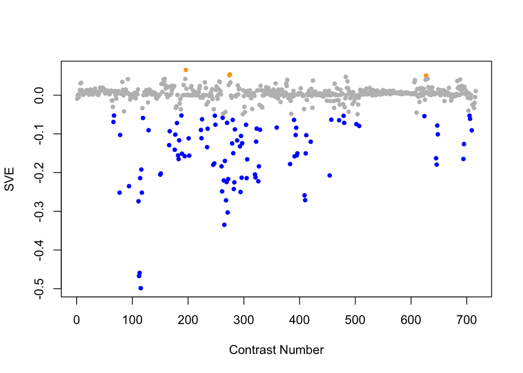

Positive SVE Contrasts:

|  | Contrast.Num | SVE | GEO.GSE | Cond.1 | Cond.2 | Mutation |
| --- | --- | --- | --- | --- | --- | --- |
| GSE43959.s1t1.vs.s3t1 | 196 | 0.07 | GSE43959 | N2 young adult on E. coli OP50 rep 1 | N2 young adult on Comamonas DA1877 rep 1 |  |
| GSE41366B.s2t2.vs.s0t2 | 275 | 0.05 | GSE41366 | high_DDVP-8h_expose-20h_harvest-rep1 | control-8h_expose-20h_harvest-rep1 |  |
| GSE41366B.s1t1.vs.s0t1 | 274 | 0.05 | GSE41366 | low_DDVP-8h_expose-14h_harvest-rep1 | control-8h_expose-14h_harvest-rep1 |  |
| GSE19310A.s5t1.vs.s0t1 | 627 | 0.05 | GSE19310 | dpy-9(e12) at iso, rep1 | N2 at iso, rep1 | dpy-9 |
| GSE23528A.s0t3.vs.s0t1 | 483 | 0.05 | GSE23528 | Adult at T10, non-entrained control time-series experiment 4 | Adult at T2, non-entrained control time-series experiment 4 |  |

Negative SVE Contrasts:

|  | Contrast.Num | SVE | GEO.GSE | Cond.1 | Cond.2 | Mutation |
| --- | --- | --- | --- | --- | --- | --- |
| GSE54024.s1t1.vs.s5t1 | 115 | -0.50 | GSE54024 | Wild type young adults, biological rep 1 | ced-4(n1162) young adults, biological rep 1 | ced-4 |
| GSE54024.s4t1.vs.s5t1 | 112 | -0.47 | GSE54024 | isp-1(qm150) young adults, biological rep 1 | ced-4(n1162) young adults, biological rep 1 |  |
| GSE54024.s3t1.vs.s5t1 | 113 | -0.46 | GSE54024 | nuo-6(qm200) young adults, biological rep 1 | ced-4(n1162) young adults, biological rep 1 |  |
| GSE41366A.s0t3.vs.s0t1 | 265 | -0.33 | GSE41366 | control-2h_expose-20h_harvest-rep1 | control-2h_expose-8h_harvest-rep1 |  |
| GSE41366A.s1t3.vs.s1t1 | 271 | -0.30 | GSE41366 | low_DDVP-2h_expose-20h_harvest-rep1 | low_DDVP-2h_expose-8h_harvest-rep1 |  |
| GSE54024.s6t1.vs.s5t1 | 111 | -0.27 | GSE54024 | isp-1(qm150) ced-4(n1162) double mutant young adults, biological rep 1 | ced-4(n1162) young adults, biological rep 1 | isp-1 |
| GSE41366A.s2t3.vs.s2t1 | 268 | -0.27 | GSE41366 | high_DDVP-2h_expose-20h_harvest-rep1 | high_DDVP-2h_expose-8h_harvest-rep1 |  |
| GSE30505.s3t2.vs.s3t1 | 410 | -0.27 | GSE30505 | Day 8 glp-1 E.V. #1 | L3 glp-1 E.V. #1 |  |
| GSE30505.s4t2.vs.s4t1 | 409 | -0.26 | GSE30505 | Day 8 glp-1 ash-2 #1 | L3 glp-1 ash-2 #1 |  |
| GSE54024.s3t1.vs.s6t1 | 117 | -0.25 | GSE54024 | nuo-6(qm200) young adults, biological rep 1 | isp-1(qm150) ced-4(n1162) double mutant young adults, biological rep 1 |  |
| GSE8004.s3t2.vs.s1t2 | 77 | -0.25 | GSE8004 | Larval Pan-neural, biological rep 1 of set 2 | Larval A-class, biological rep 1 of set 3 |  |
| GSE41366C.s1t3.vs.s0t3 | 294 | -0.25 | GSE41366 | low_DDVP-continuous_expose-14h_harvest-rep1 | control-continuous_expose-8h_harvest-rep1 |  |
| GSE41366A.s1t4.vs.s0t4 | 261 | -0.25 | GSE41366 | low_DDVP-2h_expose-26h_harvest-rep1 | control-2h_expose-26h_harvest-rep1 |  |
| GSE41366B.s2t3.vs.s2t1 | 282 | -0.24 | GSE41366 | high_DDVP-8h_expose-26h_harvest-rep1 | high_DDVP-8h_expose-14h_harvest-rep1 |  |
| GSE5801.s3t1.vs.s2t1 | 94 | -0.24 | GSE5801 | daf2pmk1_RepA | daf2daf16_RepA |  |
| GSE41366B.s1t2.vs.s1t1 | 283 | -0.23 | GSE41366 | low_DDVP-8h_expose-20h_harvest-rep1 | low_DDVP-8h_expose-14h_harvest-rep1 |  |
| GSE41366A.s2t4.vs.s2t1 | 269 | -0.22 | GSE41366 | high_DDVP-2h_expose-26h_harvest-rep1 | high_DDVP-2h_expose-8h_harvest-rep1 |  |
| GSE38997.s2t4.vs.s1t4 | 326 | -0.22 | GSE38997 | experiment 1 EtBr-exposed samples at 51 h 1e51 | experiment 1 control samples at 51 h 1c51 |  |
| GSE41366A.s0t2.vs.s0t1 | 264 | -0.22 | GSE41366 | control-2h_expose-14h_harvest-rep1 | control-2h_expose-8h_harvest-rep1 |  |
| GSE41366A.s1t4.vs.s1t1 | 272 | -0.22 | GSE41366 | low_DDVP-2h_expose-26h_harvest-rep1 | low_DDVP-2h_expose-8h_harvest-rep1 |  |
| GSE54024.s2t1.vs.s5t1 | 114 | -0.21 | GSE54024 | Wild type young adults treated with 0.1mM paraquat, biological rep 1 | ced-4(n1162) young adults, biological rep 1 |  |
| GSE41366C.s1t4.vs.s1t1 | 305 | -0.21 | GSE41366 | low_DDVP-continuous_expose-20h_harvest-rep1 | low_DDVP-continuous_expose-2h_harvest-rep1 |  |
| GSE41366C.s0t5.vs.s0t1 | 296 | -0.21 | GSE41366 | control-continuous_expose-20h_harvest-rep1 | control-continuous_expose-0h_harvest-rep2 |  |
| GSE38997.s3t3.vs.s1t3 | 321 | -0.21 | GSE38997 | experiment 1 UVC- and EtBr-exposed samples at 48 h 1eu48 | experiment 1 control samples at 48 h 1c48 |  |
| GSE25513.s2t1.vs.s0t1 | 454 | -0.21 | GSE25513 | crh-1 null (1) | WT (1) | crh-1 |
| GSE47778.s2t1.vs.s3t1 | 150 | -0.21 | GSE47778 | daf-2; replicate 1 | daf-16; replicate 1 | daf-2 vs. daf-16 |
| GSE38997.s2t3.vs.s1t3 | 320 | -0.20 | GSE38997 | experiment 1 EtBr-exposed samples at 48 h 1e48 | experiment 1 control samples at 48 h 1c48 |  |
| GSE47778.s4t1.vs.s3t1 | 151 | -0.20 | GSE47778 | daf-2;daf-16; replicate 1 | daf-16; replicate 1 | daf-2;daf-16 vs. daf-16 |
| GSE54024.s4t1.vs.s6t1 | 116 | -0.19 | GSE54024 | isp-1(qm150) young adults, biological rep 1 | isp-1(qm150) ced-4(n1162) double mutant young adults, biological rep 1 | ced-4 |
| GSE38997.s3t4.vs.s1t4 | 327 | -0.18 | GSE38997 | experiment 1 UVC- and EtBr-exposed samples at 51 h 1eu51 | experiment 1 control samples at 51 h 1c51 |  |

[output cut: 71 more lines]

$~$

$~$

#### GO Term Enrichment:

This analysis tests each hemi-module for enrichment of specific GO terms. Only gene-level annotations (e.g., as would be found on the gene’s page in Wormbase) are tested - the hierarchical structure of the GO ontology is not taken into account.

*Note: At least the top two most enriched terms from each GO domain (BP/MF/CC) are shown, even when not statistically significant.*

##### Enriched GO terms: Hemi-module A

| ID | GO.Term | GO Domain | Raw p-value | Adj p-value |
| --- | --- | --- | --- | --- |
| [GO_0042338](http://amigo.geneontology.org/amigo/term/GO:0042338) | cuticle development involved in collagen and cuticulin-based cuticle molting cycle | BP | 2.98e-10 | 1.09e-06 |
| [GO_0018996](http://amigo.geneontology.org/amigo/term/GO:0018996) | molting cycle, collagen and cuticulin-based cuticle | BP | 5.81e-08 | 1.06e-04 |
| [GO_0040002](http://amigo.geneontology.org/amigo/term/GO:0040002) | collagen and cuticulin-based cuticle development | BP | 4.95e-06 | 6.01e-03 |
| [GO_0030968](http://amigo.geneontology.org/amigo/term/GO:0030968) | endoplasmic reticulum unfolded protein response | BP | 1.08e-05 | 9.81e-03 |
| [GO_0030198](http://amigo.geneontology.org/amigo/term/GO:0030198) | extracellular matrix organization | BP | 5.39e-05 | 3.92e-02 |
| [GO_0006508](http://amigo.geneontology.org/amigo/term/GO:0006508) | proteolysis | BP | 7.37e-05 | 4.48e-02 |
| [GO_0010951](http://amigo.geneontology.org/amigo/term/GO:0010951) | negative regulation of endopeptidase activity | BP | 1.84e-04 | 8.45e-02 |
| [GO_0007267](http://amigo.geneontology.org/amigo/term/GO:0007267) | cell-cell signaling | BP | 1.86e-04 | 8.45e-02 |
| [GO_0042302](http://amigo.geneontology.org/amigo/term/GO:0042302) | structural constituent of cuticle | MF | 6.29e-45 | 1.28e-41 |
| [GO_0042329](http://amigo.geneontology.org/amigo/term/GO:0042329) | structural constituent of collagen and cuticulin-based cuticle | MF | 1.64e-07 | 1.67e-04 |
| [GO_0005201](http://amigo.geneontology.org/amigo/term/GO:0005201) | extracellular matrix structural constituent | MF | 2.09e-05 | 1.42e-02 |
| [GO_0004867](http://amigo.geneontology.org/amigo/term/GO:0004867) | serine-type endopeptidase inhibitor activity | MF | 7.10e-05 | 3.62e-02 |
| [GO_0005515](http://amigo.geneontology.org/amigo/term/GO:0005515) | protein binding | MF | 1.87e-04 | 7.65e-02 |
| [GO_0005581](http://amigo.geneontology.org/amigo/term/GO:0005581) | collagen trimer | CC | 2.92e-15 | 2.71e-12 |
| [GO_0005615](http://amigo.geneontology.org/amigo/term/GO:0005615) | extracellular space | CC | 6.12e-11 | 2.84e-08 |
| [GO_0005634](http://amigo.geneontology.org/amigo/term/GO:0005634) | nucleus | CC | 1.09e-08 | 3.36e-06 |
| [GO_0005576](http://amigo.geneontology.org/amigo/term/GO:0005576) | extracellular region | CC | 3.67e-08 | 8.51e-06 |
| [GO_0060102](http://amigo.geneontology.org/amigo/term/GO:0060102) | collagen and cuticulin-based cuticle extracellular matrix | CC | 8.69e-07 | 1.61e-04 |
| [GO_0031012](http://amigo.geneontology.org/amigo/term/GO:0031012) | extracellular matrix | CC | 9.19e-05 | 1.42e-02 |

##### Enriched GO terms: Hemi-module B

| ID | GO.Term | GO Domain | Raw p-value | Adj p-value |
| --- | --- | --- | --- | --- |
| [GO_0046487](http://amigo.geneontology.org/amigo/term/GO:0046487) | glyoxylate metabolic process | BP | 1.83e-03 | 1.00e+00 |
| [GO_0055114](http://amigo.geneontology.org/amigo/term/GO:0055114) | oxidation-reduction process | BP | 1.94e-03 | 1.00e+00 |
| [GO_0004222](http://amigo.geneontology.org/amigo/term/GO:0004222) | metalloendopeptidase activity | MF | 6.39e-04 | 1.00e+00 |
| [GO_0008237](http://amigo.geneontology.org/amigo/term/GO:0008237) | metallopeptidase activity | MF | 1.04e-03 | 1.00e+00 |
| [GO_0005818](http://amigo.geneontology.org/amigo/term/GO:0005818) | aster | CC | 7.29e-03 | 1.00e+00 |
| [GO_0005828](http://amigo.geneontology.org/amigo/term/GO:0005828) | kinetochore microtubule | CC | 7.29e-03 | 1.00e+00 |

$~$

$~$

#### Tissue Enrichment:

This analysis tests each hemi-module for enrichment of genes associated with anatomy terms. Negative enrichment scores indicate fewer hemi-module genes than expected by random chance were associated with the anatomy term in question.

##### Enriched tissues: Hemi-module A

| ID | Anatomy.Term | Definition | Raw p-value | Adj p-value |
| --- | --- | --- | --- | --- |
| [WBbt_0005734](https://wormbase.org/species/all/anatomy_term/WBbt:0005734) | hyp7 syncytium | entire syncytium of hyp7 | 6.29e-11 | 1.53e-07 |
| [WBbt_0005733](https://wormbase.org/species/all/anatomy_term/WBbt:0005733) | hypodermis | Epidermal layer. | 1.07e-08 | 1.31e-05 |
| [WBbt_0005753](https://wormbase.org/species/all/anatomy_term/WBbt:0005753) | seam cell | a group of hypodermal cells that lie along the apical midline of the hypodermis, at the extreme left and right sides between nose and tail | 1.65e-05 | 1.34e-02 |
| [WBbt_0004679](https://wormbase.org/species/all/anatomy_term/WBbt:0004679) | hyp6 | Cylindrical hypodermal syncytium in head | 1.36e-04 | 8.27e-02 |

##### Enriched tissues: Hemi-module B

No significant annotations.

$~$

$~$

#### HOMER promoter motif enrichment:

This analysis tests each hemi-module for enrichment of 108 known *C. elegans* transcription factor binding site motifs (see [108 CE motifs](https://katiepod.github.io//all.worm.motifs.html)) using the HOMER (Hypergeometric Optimization of Motif EnRichment) software (see [PMID:20513432](https://pubmed.ncbi.nlm.nih.gov/20513432)). HOMER was run using default parameters on sequences 1 kb upstream of the transcription start site.

##### Motif enrichment: Hemi-module A

Total target sequences = 239  
Total background sequences = 40008  
* - possible false positive

Rank

Motif

P-value

log P-pvalue

% of Targets

% of Background

STD(Bg STD)

Best Match/Details

Motif File

1

[figure not shown]

1e-14

-3.328e+01

39.75%

17.98%

277.6bp (375.4bp)

POL012.1_TATA-Box/Jaspar(0.872)  
[More Information](https://katiepod.github.io/HomerResults/m205_a_hemi_genes.txt.out.1kb/homerResults/motif1.info.html) | [Similar Motifs Found](https://katiepod.github.io/HomerResults/m205_a_hemi_genes.txt.out.1kb/homerResults/motif1.similar.html)

[motif file (matrix)](https://katiepod.github.io/HomerResults/m205_a_hemi_genes.txt.out.1kb/homerResults/motif1.motif)

2

[figure not shown]

1e-13

-3.202e+01

45.19%

22.58%

246.1bp (359.0bp)

MF0006.1_bZIP_cEBP-like_subclass/Jaspar(0.823)  
[More Information](https://katiepod.github.io/HomerResults/m205_a_hemi_genes.txt.out.1kb/homerResults/motif2.info.html) | [Similar Motifs Found](https://katiepod.github.io/HomerResults/m205_a_hemi_genes.txt.out.1kb/homerResults/motif2.similar.html)

[motif file (matrix)](https://katiepod.github.io/HomerResults/m205_a_hemi_genes.txt.out.1kb/homerResults/motif2.motif)

3

[figure not shown]

1e-12

-2.933e+01

6.69%

0.48%

247.6bp (324.9bp)

skn-1/MA0547.1/Jaspar(0.636)  
[More Information](https://katiepod.github.io/HomerResults/m205_a_hemi_genes.txt.out.1kb/homerResults/motif3.info.html) | [Similar Motifs Found](https://katiepod.github.io/HomerResults/m205_a_hemi_genes.txt.out.1kb/homerResults/motif3.similar.html)

[motif file (matrix)](https://katiepod.github.io/HomerResults/m205_a_hemi_genes.txt.out.1kb/homerResults/motif3.motif)

4

[figure not shown]

1e-12

-2.919e+01

5.44%

0.25%

288.2bp (416.5bp)

blmp-1/MA0537.1/Jaspar(0.627)  
[More Information](https://katiepod.github.io/HomerResults/m205_a_hemi_genes.txt.out.1kb/homerResults/motif4.info.html) | [Similar Motifs Found](https://katiepod.github.io/HomerResults/m205_a_hemi_genes.txt.out.1kb/homerResults/motif4.similar.html)

[motif file (matrix)](https://katiepod.github.io/HomerResults/m205_a_hemi_genes.txt.out.1kb/homerResults/motif4.motif)

5

[figure not shown]

1e-12

-2.886e+01

7.95%

0.81%

256.5bp (354.9bp)

POL004.1_CCAAT-box/Jaspar(0.562)  
[More Information](https://katiepod.github.io/HomerResults/m205_a_hemi_genes.txt.out.1kb/homerResults/motif5.info.html) | [Similar Motifs Found](https://katiepod.github.io/HomerResults/m205_a_hemi_genes.txt.out.1kb/homerResults/motif5.similar.html)

[motif file (matrix)](https://katiepod.github.io/HomerResults/m205_a_hemi_genes.txt.out.1kb/homerResults/motif5.motif)

6

[figure not shown]

1e-12

-2.869e+01

8.79%

1.05%

291.3bp (333.7bp)

MF0008.1_MADS_class/Jaspar(0.635)  
[More Information](https://katiepod.github.io/HomerResults/m205_a_hemi_genes.txt.out.1kb/homerResults/motif6.info.html) | [Similar Motifs Found](https://katiepod.github.io/HomerResults/m205_a_hemi_genes.txt.out.1kb/homerResults/motif6.similar.html)

[motif file (matrix)](https://katiepod.github.io/HomerResults/m205_a_hemi_genes.txt.out.1kb/homerResults/motif6.motif)

7

[figure not shown]

1e-12

-2.868e+01

17.15%

4.53%

250.8bp (368.9bp)

blmp-1/MA0537.1/Jaspar(0.706)  
[More Information](https://katiepod.github.io/HomerResults/m205_a_hemi_genes.txt.out.1kb/homerResults/motif7.info.html) | [Similar Motifs Found](https://katiepod.github.io/HomerResults/m205_a_hemi_genes.txt.out.1kb/homerResults/motif7.similar.html)

[motif file (matrix)](https://katiepod.github.io/HomerResults/m205_a_hemi_genes.txt.out.1kb/homerResults/motif7.motif)

8

[figure not shown]

1e-12

-2.863e+01

5.86%

0.34%

237.6bp (295.1bp)

POL004.1_CCAAT-box/Jaspar(0.629)  
[More Information](https://katiepod.github.io/HomerResults/m205_a_hemi_genes.txt.out.1kb/homerResults/motif8.info.html) | [Similar Motifs Found](https://katiepod.github.io/HomerResults/m205_a_hemi_genes.txt.out.1kb/homerResults/motif8.similar.html)

[motif file (matrix)](https://katiepod.github.io/HomerResults/m205_a_hemi_genes.txt.out.1kb/homerResults/motif8.motif)

9 *

[figure not shown]

1e-11

-2.713e+01

14.64%

3.51%

271.7bp (373.5bp)

elt-2/MA1701.1/Jaspar(0.609)  
[More Information](https://katiepod.github.io/HomerResults/m205_a_hemi_genes.txt.out.1kb/homerResults/motif9.info.html) | [Similar Motifs Found](https://katiepod.github.io/HomerResults/m205_a_hemi_genes.txt.out.1kb/homerResults/motif9.similar.html)

[motif file (matrix)](https://katiepod.github.io/HomerResults/m205_a_hemi_genes.txt.out.1kb/homerResults/motif9.motif)

10 *

[figure not shown]

1e-11

-2.626e+01

5.86%

0.41%

257.2bp (420.7bp)

POL011.1_XCPE1/Jaspar(0.636)  
[More Information](https://katiepod.github.io/HomerResults/m205_a_hemi_genes.txt.out.1kb/homerResults/motif10.info.html) | [Similar Motifs Found](https://katiepod.github.io/HomerResults/m205_a_hemi_genes.txt.out.1kb/homerResults/motif10.similar.html)

[motif file (matrix)](https://katiepod.github.io/HomerResults/m205_a_hemi_genes.txt.out.1kb/homerResults/motif10.motif)

11 *

[figure not shown]

1e-11

-2.616e+01

10.88%

1.97%

247.4bp (375.0bp)

SD0003.1_at_AC_acceptor/Jaspar(0.645)  
[More Information](https://katiepod.github.io/HomerResults/m205_a_hemi_genes.txt.out.1kb/homerResults/motif11.info.html) | [Similar Motifs Found](https://katiepod.github.io/HomerResults/m205_a_hemi_genes.txt.out.1kb/homerResults/motif11.similar.html)

[motif file (matrix)](https://katiepod.github.io/HomerResults/m205_a_hemi_genes.txt.out.1kb/homerResults/motif11.motif)

12 *

[figure not shown]

1e-11

-2.615e+01

2.93%

0.03%

271.1bp (403.7bp)

POL010.1_DCE_S_III/Jaspar(0.519)  
[More Information](https://katiepod.github.io/HomerResults/m205_a_hemi_genes.txt.out.1kb/homerResults/motif12.info.html) | [Similar Motifs Found](https://katiepod.github.io/HomerResults/m205_a_hemi_genes.txt.out.1kb/homerResults/motif12.similar.html)

[motif file (matrix)](https://katiepod.github.io/HomerResults/m205_a_hemi_genes.txt.out.1kb/homerResults/motif12.motif)

13 *

[figure not shown]

1e-11

-2.593e+01

20.50%

6.83%

294.9bp (332.1bp)

ceh-38/MA1699.1/Jaspar(0.604)  
[More Information](https://katiepod.github.io/HomerResults/m205_a_hemi_genes.txt.out.1kb/homerResults/motif13.info.html) | [Similar Motifs Found](https://katiepod.github.io/HomerResults/m205_a_hemi_genes.txt.out.1kb/homerResults/motif13.similar.html)

[motif file (matrix)](https://katiepod.github.io/HomerResults/m205_a_hemi_genes.txt.out.1kb/homerResults/motif13.motif)

14 *

[figure not shown]

1e-11

-2.536e+01

28.87%

12.35%

283.7bp (383.0bp)

POL003.1_GC-box/Jaspar(0.802)  
[More Information](https://katiepod.github.io/HomerResults/m205_a_hemi_genes.txt.out.1kb/homerResults/motif14.info.html) | [Similar Motifs Found](https://katiepod.github.io/HomerResults/m205_a_hemi_genes.txt.out.1kb/homerResults/motif14.similar.html)

[motif file (matrix)](https://katiepod.github.io/HomerResults/m205_a_hemi_genes.txt.out.1kb/homerResults/motif14.motif)

15 *

[figure not shown]

1e-10

-2.492e+01

12.55%

2.81%

300.5bp (364.1bp)

POL004.1_CCAAT-box/Jaspar(0.639)  
[More Information](https://katiepod.github.io/HomerResults/m205_a_hemi_genes.txt.out.1kb/homerResults/motif15.info.html) | [Similar Motifs Found](https://katiepod.github.io/HomerResults/m205_a_hemi_genes.txt.out.1kb/homerResults/motif15.similar.html)

[motif file (matrix)](https://katiepod.github.io/HomerResults/m205_a_hemi_genes.txt.out.1kb/homerResults/motif15.motif)

16 *

[figure not shown]

1e-10

-2.451e+01

5.02%

0.30%

285.3bp (364.7bp)

eor-1/MA0543.1/Jaspar(0.745)  
[More Information](https://katiepod.github.io/HomerResults/m205_a_hemi_genes.txt.out.1kb/homerResults/motif16.info.html) | [Similar Motifs Found](https://katiepod.github.io/HomerResults/m205_a_hemi_genes.txt.out.1kb/homerResults/motif16.similar.html)

[motif file (matrix)](https://katiepod.github.io/HomerResults/m205_a_hemi_genes.txt.out.1kb/homerResults/motif16.motif)

17 *

[figure not shown]

1e-10

-2.438e+01

7.95%

1.06%

208.3bp (384.9bp)

elt-2/MA1701.1/Jaspar(0.649)  
[More Information](https://katiepod.github.io/HomerResults/m205_a_hemi_genes.txt.out.1kb/homerResults/motif17.info.html) | [Similar Motifs Found](https://katiepod.github.io/HomerResults/m205_a_hemi_genes.txt.out.1kb/homerResults/motif17.similar.html)

[motif file (matrix)](https://katiepod.github.io/HomerResults/m205_a_hemi_genes.txt.out.1kb/homerResults/motif17.motif)

18 *

[figure not shown]

1e-9

-2.208e+01

6.69%

0.81%

265.3bp (330.3bp)

blmp-1/MA0537.1/Jaspar(0.593)  
[More Information](https://katiepod.github.io/HomerResults/m205_a_hemi_genes.txt.out.1kb/homerResults/motif18.info.html) | [Similar Motifs Found](https://katiepod.github.io/HomerResults/m205_a_hemi_genes.txt.out.1kb/homerResults/motif18.similar.html)

[motif file (matrix)](https://katiepod.github.io/HomerResults/m205_a_hemi_genes.txt.out.1kb/homerResults/motif18.motif)

19 *

[figure not shown]

1e-9

-2.143e+01

7.11%

0.98%

278.9bp (346.7bp)

blmp-1/MA0537.1/Jaspar(0.654)  
[More Information](https://katiepod.github.io/HomerResults/m205_a_hemi_genes.txt.out.1kb/homerResults/motif19.info.html) | [Similar Motifs Found](https://katiepod.github.io/HomerResults/m205_a_hemi_genes.txt.out.1kb/homerResults/motif19.similar.html)

[motif file (matrix)](https://katiepod.github.io/HomerResults/m205_a_hemi_genes.txt.out.1kb/homerResults/motif19.motif)

20 *

[figure not shown]

1e-9

-2.141e+01

3.35%

0.10%

288.1bp (357.9bp)

MF0004.1_Nuclear_Receptor_class/Jaspar(0.616)  
[More Information](https://katiepod.github.io/HomerResults/m205_a_hemi_genes.txt.out.1kb/homerResults/motif20.info.html) | [Similar Motifs Found](https://katiepod.github.io/HomerResults/m205_a_hemi_genes.txt.out.1kb/homerResults/motif20.similar.html)

[motif file (matrix)](https://katiepod.github.io/HomerResults/m205_a_hemi_genes.txt.out.1kb/homerResults/motif20.motif)

21 *

[figure not shown]

1e-9

-2.085e+01

5.44%

0.52%

229.8bp (366.0bp)

unc-30/MA1443.1/Jaspar(0.530)  
[More Information](https://katiepod.github.io/HomerResults/m205_a_hemi_genes.txt.out.1kb/homerResults/motif21.info.html) | [Similar Motifs Found](https://katiepod.github.io/HomerResults/m205_a_hemi_genes.txt.out.1kb/homerResults/motif21.similar.html)

[motif file (matrix)](https://katiepod.github.io/HomerResults/m205_a_hemi_genes.txt.out.1kb/homerResults/motif21.motif)

22 *

[figure not shown]

1e-8

-2.064e+01

10.04%

2.19%

325.7bp (345.2bp)

pal-1/MA0924.1/Jaspar(0.737)  
[More Information](https://katiepod.github.io/HomerResults/m205_a_hemi_genes.txt.out.1kb/homerResults/motif22.info.html) | [Similar Motifs Found](https://katiepod.github.io/HomerResults/m205_a_hemi_genes.txt.out.1kb/homerResults/motif22.similar.html)

[motif file (matrix)](https://katiepod.github.io/HomerResults/m205_a_hemi_genes.txt.out.1kb/homerResults/motif22.motif)

23 *

[figure not shown]

1e-8

-2.056e+01

14.64%

4.49%

254.9bp (376.8bp)

blmp-1/MA0537.1/Jaspar(0.627)  
[More Information](https://katiepod.github.io/HomerResults/m205_a_hemi_genes.txt.out.1kb/homerResults/motif23.info.html) | [Similar Motifs Found](https://katiepod.github.io/HomerResults/m205_a_hemi_genes.txt.out.1kb/homerResults/motif23.similar.html)

[motif file (matrix)](https://katiepod.github.io/HomerResults/m205_a_hemi_genes.txt.out.1kb/homerResults/motif23.motif)

24 *

[figure not shown]

1e-8

-1.999e+01

16.32%

5.55%

284.6bp (336.2bp)

POL012.1_TATA-Box/Jaspar(0.624)  
[More Information](https://katiepod.github.io/HomerResults/m205_a_hemi_genes.txt.out.1kb/homerResults/motif24.info.html) | [Similar Motifs Found](https://katiepod.github.io/HomerResults/m205_a_hemi_genes.txt.out.1kb/homerResults/motif24.similar.html)

[motif file (matrix)](https://katiepod.github.io/HomerResults/m205_a_hemi_genes.txt.out.1kb/homerResults/motif24.motif)

25 *

[figure not shown]

1e-8

-1.990e+01

46.03%

27.93%

280.2bp (393.0bp)

unc-30/MA1443.1/Jaspar(0.645)  
[More Information](https://katiepod.github.io/HomerResults/m205_a_hemi_genes.txt.out.1kb/homerResults/motif25.info.html) | [Similar Motifs Found](https://katiepod.github.io/HomerResults/m205_a_hemi_genes.txt.out.1kb/homerResults/motif25.similar.html)

[motif file (matrix)](https://katiepod.github.io/HomerResults/m205_a_hemi_genes.txt.out.1kb/homerResults/motif25.motif)

26 *

[figure not shown]

1e-8

-1.886e+01

7.95%

1.49%

299.8bp (407.4bp)

MF0002.1_bZIP_CREB/G-box-like_subclass/Jaspar(0.651)  
[More Information](https://katiepod.github.io/HomerResults/m205_a_hemi_genes.txt.out.1kb/homerResults/motif26.info.html) | [Similar Motifs Found](https://katiepod.github.io/HomerResults/m205_a_hemi_genes.txt.out.1kb/homerResults/motif26.similar.html)

[motif file (matrix)](https://katiepod.github.io/HomerResults/m205_a_hemi_genes.txt.out.1kb/homerResults/motif26.motif)

27 *

[figure not shown]

1e-7

-1.812e+01

36.40%

20.56%

298.5bp (353.8bp)

MF0009.1_TRP(MYB)_class/Jaspar(0.732)  
[More Information](https://katiepod.github.io/HomerResults/m205_a_hemi_genes.txt.out.1kb/homerResults/motif27.info.html) | [Similar Motifs Found](https://katiepod.github.io/HomerResults/m205_a_hemi_genes.txt.out.1kb/homerResults/motif27.similar.html)

[motif file (matrix)](https://katiepod.github.io/HomerResults/m205_a_hemi_genes.txt.out.1kb/homerResults/motif27.motif)

28 *

[figure not shown]

1e-7

-1.613e+01

7.95%

1.78%

254.2bp (350.8bp)

PL0017.1_hlh-2::hlh-10/Jaspar(0.571)  
[More Information](https://katiepod.github.io/HomerResults/m205_a_hemi_genes.txt.out.1kb/homerResults/motif28.info.html) | [Similar Motifs Found](https://katiepod.github.io/HomerResults/m205_a_hemi_genes.txt.out.1kb/homerResults/motif28.similar.html)

[motif file (matrix)](https://katiepod.github.io/HomerResults/m205_a_hemi_genes.txt.out.1kb/homerResults/motif28.motif)

29 *

[figure not shown]

1e-6

-1.451e+01

5.02%

0.76%

194.8bp (341.1bp)

MF0003.1_REL_class/Jaspar(0.593)  
[More Information](https://katiepod.github.io/HomerResults/m205_a_hemi_genes.txt.out.1kb/homerResults/motif29.info.html) | [Similar Motifs Found](https://katiepod.github.io/HomerResults/m205_a_hemi_genes.txt.out.1kb/homerResults/motif29.similar.html)

[motif file (matrix)](https://katiepod.github.io/HomerResults/m205_a_hemi_genes.txt.out.1kb/homerResults/motif29.motif)

30 *

[figure not shown]

1e-6

-1.412e+01

8.79%

2.46%

308.3bp (342.3bp)

elt-6/MA1439.1/Jaspar(0.586)  
[More Information](https://katiepod.github.io/HomerResults/m205_a_hemi_genes.txt.out.1kb/homerResults/motif30.info.html) | [Similar Motifs Found](https://katiepod.github.io/HomerResults/m205_a_hemi_genes.txt.out.1kb/homerResults/motif30.similar.html)

[motif file (matrix)](https://katiepod.github.io/HomerResults/m205_a_hemi_genes.txt.out.1kb/homerResults/motif30.motif)

31 *

[figure not shown]

1e-5

-1.190e+01

31.38%

19.34%

268.5bp (354.8bp)

unc-86/MA0926.1/Jaspar(0.642)  
[More Information](https://katiepod.github.io/HomerResults/m205_a_hemi_genes.txt.out.1kb/homerResults/motif31.info.html) | [Similar Motifs Found](https://katiepod.github.io/HomerResults/m205_a_hemi_genes.txt.out.1kb/homerResults/motif31.similar.html)

[motif file (matrix)](https://katiepod.github.io/HomerResults/m205_a_hemi_genes.txt.out.1kb/homerResults/motif31.motif)

32 *

[figure not shown]

1e-5

-1.188e+01

20.92%

11.01%

248.5bp (398.6bp)

DPL-1(E2F)/cElegans-Adult-ChIP-Seq(modEncode)/Homer(0.676)  
[More Information](https://katiepod.github.io/HomerResults/m205_a_hemi_genes.txt.out.1kb/homerResults/motif32.info.html) | [Similar Motifs Found](https://katiepod.github.io/HomerResults/m205_a_hemi_genes.txt.out.1kb/homerResults/motif32.similar.html)

[motif file (matrix)](https://katiepod.github.io/HomerResults/m205_a_hemi_genes.txt.out.1kb/homerResults/motif32.motif)

33 *

[figure not shown]

1e-4

-1.078e+01

8.37%

2.83%

255.3bp (353.0bp)

EGL-5(Homeobox)/cElegans-L3-EGL5-ChIP-Seq(modEncode)/Homer(0.596)  
[More Information](https://katiepod.github.io/HomerResults/m205_a_hemi_genes.txt.out.1kb/homerResults/motif33.info.html) | [Similar Motifs Found](https://katiepod.github.io/HomerResults/m205_a_hemi_genes.txt.out.1kb/homerResults/motif33.similar.html)

[motif file (matrix)](https://katiepod.github.io/HomerResults/m205_a_hemi_genes.txt.out.1kb/homerResults/motif33.motif)

34 *

[figure not shown]

1e-4

-1.023e+01

29.71%

18.85%

243.0bp (342.9bp)

fkh-9/MA1440.1/Jaspar(0.570)  
[More Information](https://katiepod.github.io/HomerResults/m205_a_hemi_genes.txt.out.1kb/homerResults/motif34.info.html) | [Similar Motifs Found](https://katiepod.github.io/HomerResults/m205_a_hemi_genes.txt.out.1kb/homerResults/motif34.similar.html)

[motif file (matrix)](https://katiepod.github.io/HomerResults/m205_a_hemi_genes.txt.out.1kb/homerResults/motif34.motif)

35 *

[figure not shown]

1e-4

-9.397e+00

3.77%

0.73%

189.5bp (334.4bp)

POL004.1_CCAAT-box/Jaspar(0.547)  
[More Information](https://katiepod.github.io/HomerResults/m205_a_hemi_genes.txt.out.1kb/homerResults/motif35.info.html) | [Similar Motifs Found](https://katiepod.github.io/HomerResults/m205_a_hemi_genes.txt.out.1kb/homerResults/motif35.similar.html)

[motif file (matrix)](https://katiepod.github.io/HomerResults/m205_a_hemi_genes.txt.out.1kb/homerResults/motif35.motif)

36 *

[figure not shown]

1e-2

-5.126e+00

0.42%

0.00%

186.2bp (0.0bp)

EGL-5(Homeobox)/cElegans-L3-EGL5-ChIP-Seq(modEncode)/Homer(0.470)  
[More Information](https://katiepod.github.io/HomerResults/m205_a_hemi_genes.txt.out.1kb/homerResults/motif36.info.html) | [Similar Motifs Found](https://katiepod.github.io/HomerResults/m205_a_hemi_genes.txt.out.1kb/homerResults/motif36.similar.html)

[motif file (matrix)](https://katiepod.github.io/HomerResults/m205_a_hemi_genes.txt.out.1kb/homerResults/motif36.motif)

37 *

[figure not shown]

1e-2

-5.126e+00

0.42%

0.00%

166.3bp (0.0bp)

pal-1/MA0924.1/Jaspar(0.616)  
[More Information](https://katiepod.github.io/HomerResults/m205_a_hemi_genes.txt.out.1kb/homerResults/motif37.info.html) | [Similar Motifs Found](https://katiepod.github.io/HomerResults/m205_a_hemi_genes.txt.out.1kb/homerResults/motif37.similar.html)

[motif file (matrix)](https://katiepod.github.io/HomerResults/m205_a_hemi_genes.txt.out.1kb/homerResults/motif37.motif)

38 *

[figure not shown]

1e-2

-4.907e+00

29.71%

22.70%

244.7bp (369.0bp)

POL009.1_DCE_S_II/Jaspar(0.480)  
[More Information](https://katiepod.github.io/HomerResults/m205_a_hemi_genes.txt.out.1kb/homerResults/motif38.info.html) | [Similar Motifs Found](https://katiepod.github.io/HomerResults/m205_a_hemi_genes.txt.out.1kb/homerResults/motif38.similar.html)

[motif file (matrix)](https://katiepod.github.io/HomerResults/m205_a_hemi_genes.txt.out.1kb/homerResults/motif38.motif)

##### Motif enrichment: Hemi-module B

Total target sequences = 26  
Total background sequences = 32004  
* - possible false positive

Rank

Motif

P-value

log P-pvalue

% of Targets

% of Background

STD(Bg STD)

Best Match/Details

Motif File

1 *

[figure not shown]

1e-9

-2.291e+01

15.38%

0.02%

112.9bp (364.2bp)

POL008.1_DCE_S_I/Jaspar(0.520)  
[More Information](https://katiepod.github.io/HomerResults/m205_b_hemi_genes.txt.out.1kb/homerResults/motif1.info.html) | [Similar Motifs Found](https://katiepod.github.io/HomerResults/m205_b_hemi_genes.txt.out.1kb/homerResults/motif1.similar.html)

[motif file (matrix)](https://katiepod.github.io/HomerResults/m205_b_hemi_genes.txt.out.1kb/homerResults/motif1.motif)

2 *

[figure not shown]

1e-9

-2.124e+01

19.23%

0.15%

217.2bp (315.0bp)

SD0003.1_at_AC_acceptor/Jaspar(0.603)  
[More Information](https://katiepod.github.io/HomerResults/m205_b_hemi_genes.txt.out.1kb/homerResults/motif2.info.html) | [Similar Motifs Found](https://katiepod.github.io/HomerResults/m205_b_hemi_genes.txt.out.1kb/homerResults/motif2.similar.html)

[motif file (matrix)](https://katiepod.github.io/HomerResults/m205_b_hemi_genes.txt.out.1kb/homerResults/motif2.motif)

3 *

[figure not shown]

1e-9

-2.098e+01

26.92%

0.74%

296.6bp (323.6bp)

unc-62/MA0918.1/Jaspar(0.638)  
[More Information](https://katiepod.github.io/HomerResults/m205_b_hemi_genes.txt.out.1kb/homerResults/motif3.info.html) | [Similar Motifs Found](https://katiepod.github.io/HomerResults/m205_b_hemi_genes.txt.out.1kb/homerResults/motif3.similar.html)

[motif file (matrix)](https://katiepod.github.io/HomerResults/m205_b_hemi_genes.txt.out.1kb/homerResults/motif3.motif)

4 *

[figure not shown]

1e-9

-2.092e+01

23.08%

0.38%

227.5bp (350.2bp)

ceh-48/MA0921.1/Jaspar(0.531)  
[More Information](https://katiepod.github.io/HomerResults/m205_b_hemi_genes.txt.out.1kb/homerResults/motif4.info.html) | [Similar Motifs Found](https://katiepod.github.io/HomerResults/m205_b_hemi_genes.txt.out.1kb/homerResults/motif4.similar.html)

[motif file (matrix)](https://katiepod.github.io/HomerResults/m205_b_hemi_genes.txt.out.1kb/homerResults/motif4.motif)

5 *

[figure not shown]

1e-8

-2.008e+01

11.54%

0.00%

267.4bp (30.0bp)

MF0009.1_TRP(MYB)_class/Jaspar(0.510)  
[More Information](https://katiepod.github.io/HomerResults/m205_b_hemi_genes.txt.out.1kb/homerResults/motif5.info.html) | [Similar Motifs Found](https://katiepod.github.io/HomerResults/m205_b_hemi_genes.txt.out.1kb/homerResults/motif5.similar.html)

[motif file (matrix)](https://katiepod.github.io/HomerResults/m205_b_hemi_genes.txt.out.1kb/homerResults/motif5.motif)

6 *

[figure not shown]

1e-7

-1.624e+01

30.77%

2.30%

246.0bp (317.6bp)

ceh-48/MA0921.1/Jaspar(0.619)  
[More Information](https://katiepod.github.io/HomerResults/m205_b_hemi_genes.txt.out.1kb/homerResults/motif6.info.html) | [Similar Motifs Found](https://katiepod.github.io/HomerResults/m205_b_hemi_genes.txt.out.1kb/homerResults/motif6.similar.html)

[motif file (matrix)](https://katiepod.github.io/HomerResults/m205_b_hemi_genes.txt.out.1kb/homerResults/motif6.motif)

7 *

[figure not shown]

1e-5

-1.317e+01

7.69%

0.00%

150.0bp (0.0bp)

POL009.1_DCE_S_II/Jaspar(0.550)  
[More Information](https://katiepod.github.io/HomerResults/m205_b_hemi_genes.txt.out.1kb/homerResults/motif7.info.html) | [Similar Motifs Found](https://katiepod.github.io/HomerResults/m205_b_hemi_genes.txt.out.1kb/homerResults/motif7.similar.html)

[motif file (matrix)](https://katiepod.github.io/HomerResults/m205_b_hemi_genes.txt.out.1kb/homerResults/motif7.motif)

8 *

[figure not shown]

1e-5

-1.260e+01

42.31%

8.37%

228.0bp (304.8bp)

POL009.1_DCE_S_II/Jaspar(0.510)  
[More Information](https://katiepod.github.io/HomerResults/m205_b_hemi_genes.txt.out.1kb/homerResults/motif8.info.html) | [Similar Motifs Found](https://katiepod.github.io/HomerResults/m205_b_hemi_genes.txt.out.1kb/homerResults/motif8.similar.html)

[motif file (matrix)](https://katiepod.github.io/HomerResults/m205_b_hemi_genes.txt.out.1kb/homerResults/motif8.motif)

9 *

[figure not shown]

1e-5

-1.260e+01

34.62%

5.11%

204.0bp (305.9bp)

fos-1/MA1448.1/Jaspar(0.726)  
[More Information](https://katiepod.github.io/HomerResults/m205_b_hemi_genes.txt.out.1kb/homerResults/motif9.info.html) | [Similar Motifs Found](https://katiepod.github.io/HomerResults/m205_b_hemi_genes.txt.out.1kb/homerResults/motif9.similar.html)

[motif file (matrix)](https://katiepod.github.io/HomerResults/m205_b_hemi_genes.txt.out.1kb/homerResults/motif9.motif)

10 *

[figure not shown]

1e-5

-1.245e+01

30.77%

3.82%

342.4bp (303.2bp)

MF0011.1_HMG_class/Jaspar(0.832)  
[More Information](https://katiepod.github.io/HomerResults/m205_b_hemi_genes.txt.out.1kb/homerResults/motif10.info.html) | [Similar Motifs Found](https://katiepod.github.io/HomerResults/m205_b_hemi_genes.txt.out.1kb/homerResults/motif10.similar.html)

[motif file (matrix)](https://katiepod.github.io/HomerResults/m205_b_hemi_genes.txt.out.1kb/homerResults/motif10.motif)

11 *

[figure not shown]

1e-4

-1.149e+01

11.54%

0.15%

295.6bp (228.9bp)

POL013.1_MED-1/Jaspar(0.666)  
[More Information](https://katiepod.github.io/HomerResults/m205_b_hemi_genes.txt.out.1kb/homerResults/motif11.info.html) | [Similar Motifs Found](https://katiepod.github.io/HomerResults/m205_b_hemi_genes.txt.out.1kb/homerResults/motif11.similar.html)

[motif file (matrix)](https://katiepod.github.io/HomerResults/m205_b_hemi_genes.txt.out.1kb/homerResults/motif11.motif)

12 *

[figure not shown]

1e-4

-1.067e+01

34.62%

6.48%

317.8bp (299.1bp)

POL003.1_GC-box/Jaspar(0.658)  
[More Information](https://katiepod.github.io/HomerResults/m205_b_hemi_genes.txt.out.1kb/homerResults/motif12.info.html) | [Similar Motifs Found](https://katiepod.github.io/HomerResults/m205_b_hemi_genes.txt.out.1kb/homerResults/motif12.similar.html)

[motif file (matrix)](https://katiepod.github.io/HomerResults/m205_b_hemi_genes.txt.out.1kb/homerResults/motif12.motif)

13 *

[figure not shown]

1e-3

-9.143e+00

19.23%

1.86%

253.0bp (324.4bp)

snpc-4/MA0544.1/Jaspar(0.803)  
[More Information](https://katiepod.github.io/HomerResults/m205_b_hemi_genes.txt.out.1kb/homerResults/motif13.info.html) | [Similar Motifs Found](https://katiepod.github.io/HomerResults/m205_b_hemi_genes.txt.out.1kb/homerResults/motif13.similar.html)

[motif file (matrix)](https://katiepod.github.io/HomerResults/m205_b_hemi_genes.txt.out.1kb/homerResults/motif13.motif)

14 *

[figure not shown]

1e-3

-7.688e+00

30.77%

7.50%

322.1bp (315.1bp)

MF0010.1_Homeobox_class/Jaspar(0.571)  
[More Information](https://katiepod.github.io/HomerResults/m205_b_hemi_genes.txt.out.1kb/homerResults/motif14.info.html) | [Similar Motifs Found](https://katiepod.github.io/HomerResults/m205_b_hemi_genes.txt.out.1kb/homerResults/motif14.similar.html)

[motif file (matrix)](https://katiepod.github.io/HomerResults/m205_b_hemi_genes.txt.out.1kb/homerResults/motif14.motif)

15 *

[figure not shown]

1e-2

-6.785e+00

15.38%

1.79%

258.2bp (306.4bp)

dpy-27/MA0540.1/Jaspar(0.685)  
[More Information](https://katiepod.github.io/HomerResults/m205_b_hemi_genes.txt.out.1kb/homerResults/motif15.info.html) | [Similar Motifs Found](https://katiepod.github.io/HomerResults/m205_b_hemi_genes.txt.out.1kb/homerResults/motif15.similar.html)

[motif file (matrix)](https://katiepod.github.io/HomerResults/m205_b_hemi_genes.txt.out.1kb/homerResults/motif15.motif)

16 *

[figure not shown]

1e-2

-5.230e+00

15.38%

2.76%

149.4bp (327.3bp)

MF0011.1_HMG_class/Jaspar(0.640)  
[More Information](https://katiepod.github.io/HomerResults/m205_b_hemi_genes.txt.out.1kb/homerResults/motif16.info.html) | [Similar Motifs Found](https://katiepod.github.io/HomerResults/m205_b_hemi_genes.txt.out.1kb/homerResults/motif16.similar.html)

[motif file (matrix)](https://katiepod.github.io/HomerResults/m205_b_hemi_genes.txt.out.1kb/homerResults/motif16.motif)

17 *

[figure not shown]

1e0

-1.217e+00

11.54%

7.32%

143.2bp (317.1bp)

ceh-28/MA1445.1/Jaspar(0.728)  
[More Information](https://katiepod.github.io/HomerResults/m205_b_hemi_genes.txt.out.1kb/homerResults/motif17.info.html) | [Similar Motifs Found](https://katiepod.github.io/HomerResults/m205_b_hemi_genes.txt.out.1kb/homerResults/motif17.similar.html)

[motif file (matrix)](https://katiepod.github.io/HomerResults/m205_b_hemi_genes.txt.out.1kb/homerResults/motif17.motif)

$~$

$~$

#### Promoter Word Enrichment:

This analysis tests each hemi-module for enrichment of specific promoter words. The list of promoter words tested was generated by running the MobyDick algorithm (see [PMID:10944202](https://pubmed.ncbi.nlm.nih.gov/10944202)) on the full set of *C. elegans* 2 Kbp promoters.

##### Enriched promoter words: Hemi-module A

| Word | RC | Raw.p.value | Adj.p.value |
| --- | --- | --- | --- |
| GTATAAAAG | CTTTTATAC | 8.21e-09 | 4.29e-05 |
| GTATAAAAGG | CCTTTTATAC | 5.37e-08 | 1.14e-04 |
| TATAAAAG | CTTTTATA | 6.53e-08 | 1.14e-04 |
| CTTTCTCTC | GAGAGAAAG | 8.79e-07 | 1.15e-03 |
| CCCCC | GGGGG | 1.42e-05 | 1.32e-02 |
| ATATCT | AGATAT | 1.52e-05 | 1.32e-02 |
| CATATCC | GGATATG | 2.07e-05 | 1.54e-02 |
| CCTTATC | GATAAGG | 2.90e-05 | 1.58e-02 |
| CCTCT | AGAGG | 3.40e-05 | 1.58e-02 |
| CCTCCC | GGGAGG | 3.56e-05 | 1.58e-02 |
| CGCGCGG | CCGCGCG | 3.62e-05 | 1.58e-02 |
| GGGCGGAGTC | GACTCCGCCC | 3.63e-05 | 1.58e-02 |
| TCGCT | AGCGA | 7.12e-05 | 2.86e-02 |
| ATCATA | TATGAT | 8.00e-05 | 2.99e-02 |
| CTCCCCC | GGGGGAG | 9.75e-05 | 3.40e-02 |
| TCCCCC | GGGGGA | 1.09e-04 | 3.45e-02 |
| TCGCTT | AAGCGA | 1.12e-04 | 3.45e-02 |
| CTTATC | GATAAG | 1.71e-04 | 4.87e-02 |
| CCGCGCG | CGCGCGG | 1.79e-04 | 4.87e-02 |
| CCGCC | GGCGG | 1.95e-04 | 4.87e-02 |
| TATCA | TGATA | 1.96e-04 | 4.87e-02 |
| CCAGCC | GGCTGG | 2.05e-04 | 4.88e-02 |
| TGGGCGG | CCGCCCA | 2.25e-04 | 5.11e-02 |
| GTATAAAA | TTTTATAC | 2.36e-04 | 5.15e-02 |
| GTAGGTC | GACCTAC | 2.49e-04 | 5.21e-02 |
| TCATCTC | GAGATGA | 3.10e-04 | 6.24e-02 |
| GGGGCGGAG | CTCCGCCCC | 3.57e-04 | 6.92e-02 |
| AGAAGAAGC | GCTTCTTCT | 3.80e-04 | 6.98e-02 |
| CCTCCCCC | GGGGGAGG | 3.87e-04 | 6.98e-02 |
| AATCTTA | TAAGATT | 4.15e-04 | 7.14e-02 |
| GATTACG | CGTAATC | 4.23e-04 | 7.14e-02 |
| TAGCCT | AGGCTA | 4.65e-04 | 7.60e-02 |
| CGTAATCC | GGATTACG | 5.15e-04 | 8.16e-02 |
| CCCTCC | GGAGGG | 6.26e-04 | 8.89e-02 |
| GTACTT | AAGTAC | 6.29e-04 | 8.89e-02 |
| CCCCGCCCAC | GTGGGCGGGG | 6.33e-04 | 8.89e-02 |
| GGTGGTGGTG | CACCACCACC | 6.35e-04 | 8.89e-02 |
| CCTAATCC | GGATTAGG | 6.49e-04 | 8.89e-02 |
| CCCTCCCC | GGGGAGGG | 6.79e-04 | 8.89e-02 |
| AAATCTTA | TAAGATTT | 6.88e-04 | 8.89e-02 |
| CCCCCTC | GAGGGGG | 6.97e-04 | 8.89e-02 |
| GTCTTC | GAAGAC | 7.88e-04 | 9.77e-02 |
| TTGGCAA | TTGCCAA | 8.03e-04 | 9.77e-02 |

##### Enriched promoter words: Hemi-module B

No significant words.

$~$

$~$

#### Promoter Word Depletion:

This analysis tests each hemi-module for depletion (under-enrichment) of specific promoter words. The list of promoter words tested was generated by running the MobyDick algorithm (see [PMID:10944202](https://pubmed.ncbi.nlm.nih.gov/10944202)) on the full set of *C. elegans* 2 Kbp promoters.

##### Depleted promoter words: Hemi-module A

| Word | RC | Raw.p.value | Adj.p.value |
| --- | --- | --- | --- |
| ATCGAT | ATCGAT | 9.48e-08 | 4.67e-04 |
| ATCGATT | AATCGAT | 1.79e-07 | 4.67e-04 |
| CACGCG | CGCGTG | 1.07e-06 | 1.87e-03 |
| GAGCA | TGCTC | 1.45e-06 | 1.90e-03 |
| GCTCA | TGAGC | 4.70e-06 | 4.91e-03 |
| GAGC | GCTC | 8.20e-06 | 7.15e-03 |
| TGCTC | GAGCA | 1.07e-05 | 7.97e-03 |
| GAGCTC | GAGCTC | 3.46e-05 | 2.15e-02 |
| GAGCC | GGCTC | 3.90e-05 | 2.15e-02 |
| AAAATCAATA | TATTGATTTT | 4.24e-05 | 2.15e-02 |
| CAATTTTC | GAAAATTG | 4.62e-05 | 2.15e-02 |
| AAATCAATAA | TTATTGATTT | 4.93e-05 | 2.15e-02 |
| TATCGAT | ATCGATA | 5.47e-05 | 2.20e-02 |
| TGAAAAAT | ATTTTTCA | 7.20e-05 | 2.69e-02 |
| AGCTC | GAGCT | 1.21e-04 | 4.22e-02 |
| AAATTTGA | TCAAATTT | 1.42e-04 | 4.65e-02 |
| TTTATAG | CTATAAA | 1.77e-04 | 5.46e-02 |
| TATCGATT | AATCGATA | 2.02e-04 | 5.87e-02 |
| CAATTTT | AAAATTG | 2.80e-04 | 7.69e-02 |
| TATTTCT | AGAAATA | 3.51e-04 | 8.27e-02 |
| AATAAAT | ATTTATT | 3.60e-04 | 8.27e-02 |
| ACGTG | CACGT | 3.72e-04 | 8.27e-02 |
| TTTGAAA | TTTCAAA | 3.73e-04 | 8.27e-02 |
| TTGAGC | GCTCAA | 3.79e-04 | 8.27e-02 |
| AATCAATAA | TTATTGATT | 4.01e-04 | 8.38e-02 |
| TTTGAA | TTCAAA | 4.84e-04 | 9.73e-02 |
| AAAAATCAATA | TATTGATTTTT | 5.05e-04 | 9.78e-02 |

##### Depleted promoter words: Hemi-module B

No significant words.

$~$

$~$

#### 3’-UTR Word Enrichment:

This analysis tests each hemi-module for enrichment of specific 3’-UTR words. The list of words tested was generated by running the MobyDick algorithm (see [PMID:10944202](https://pubmed.ncbi.nlm.nih.gov/10944202)) on the full set of *C. elegans* 3’-UTR sequences.

##### 3’-UTR words: Hemi-module A

| Word | RC | Raw.p.value | Adj.p.value |
| --- | --- | --- | --- |
| TAATAA | TTATTA | 4.56e-11 | 4.39e-08 |

##### 3’-UTR words: Hemi-module B

No significant words.

$~$

$~$

#### Hemi-module A genes

| affy_c_elegans | ensembl_gene_id | external_gene_name | module_weight | chromosome_name | strand | start_position | end_position |
| --- | --- | --- | --- | --- | --- | --- | --- |
| 173576_at | WBGene00022679 | ZK180.5 | 11.64 | IV | -1 | 4515044 | 4517169 |
| 172325_x_at | WBGene00015340 | C02E7.7 | 10.97 | V | -1 | 4918154 | 4918585 |
| 172497_x_at | WBGene00020040 | R12E2.15 | 10.37 | I | -1 | 4148832 | 4149429 |
| 172741_x_at | WBGene00018297 | F41F3.3 | 10.05 | V | -1 | 4647665 | 4648241 |
| 172353_x_at | WBGene00015339 | C02E7.6 | 9.87 | V | 1 | 4919207 | 4919586 |
| 180505_at | WBGene00004120 | pqn-32 | 9.76 | II | 1 | 13108019 | 13110169 |
| 172799_x_at | WBGene00009983 | cut-2 | 9.58 | V | 1 | 13414902 | 13416121 |
| 174075_at | WBGene00006651 | tts-2 | 9.55 | II | -1 | 10201125 | 10202230 |
| 191688_at | WBGene00008851 | F15B9.8 | 9.17 | V | 1 | 12988543 | 12992185 |
| 171795_x_at | WBGene00020039 | R12E2.14 | 8.97 | I | 1 | 4149981 | 4150634 |
| 172547_x_at | WBGene00020039 | R12E2.14 | 8.93 | I | 1 | 4149981 | 4150634 |
| 188747_at | WBGene00000625 | col-48 | 8.93 | I | 1 | 3010688 | 3011648 |
| 188747_at | WBGene00197714 | Y54E10BL.8 | 8.93 | I | 1 | 3010493 | 3010618 |
| 171796_x_at | WBGene00015339 | C02E7.6 | 8.73 | V | 1 | 4919207 | 4919586 |
| 175393_at | WBGene00021625 | Y47D7A.13 | 8.71 | V | -1 | 4434883 | 4435928 |
| 191001_s_at | WBGene00019184 | H10E21.4 | 8.66 | III | -1 | 17316 | 19675 |
| 173083_s_at | WBGene00019184 | H10E21.4 | 8.64 | III | -1 | 17316 | 19675 |
| 172346_x_at | WBGene00020033 | R12E2.7 | 8.50 | I | -1 | 4153957 | 4154550 |
| 182104_at | WBGene00014183 | ZK1025.3 | 8.45 | I | -1 | 11460780 | 11463074 |
| 193327_at | WBGene00018737 | F53B1.4 | 8.44 | X | -1 | 2111397 | 2113103 |
| 184102_s_at | WBGene00014182 | ZK1025.2 | 8.34 | I | -1 | 11449856 | 11451972 |
| 184102_s_at | WBGene00014188 | ZK1025.8 | 8.34 | I | 1 | 11469462 | 11471584 |
| 173235_at | WBGene00000683 | col-109 | 8.25 | IV | -1 | 1817311 | 1820253 |
| 182561_at | WBGene00012433 | Y11D7A.9 | 8.24 | IV | -1 | 9253979 | 9256117 |
| 174910_at | WBGene00005018 | sqt-3 | 8.04 | V | 1 | 12352994 | 12354314 |
| 183975_s_at | WBGene00004133 | abu-13 | 8.02 | III | -1 | 6941889 | 6945895 |
| 172706_x_at | WBGene00009982 | F53F1.4 | 7.98 | V | 1 | 13411077 | 13411717 |
| 173004_s_at | WBGene00001716 | grl-7 | 7.84 | V | -1 | 11344831 | 11347012 |
| 179686_at | WBGene00007999 | tag-297 | 7.73 | II | 1 | 14627630 | 14630121 |
| 183230_at | WBGene00044724 | R02E4.3 | 7.73 | X | -1 | 4101687 | 4102125 |

[output cut: 299 more lines]

#### Hemi-module B genes

| affy_c_elegans | ensembl_gene_id | external_gene_name | module_weight | chromosome_name | strand | start_position | end_position |
| --- | --- | --- | --- | --- | --- | --- | --- |
| 177218_at | WBGene00021805 | Y53G8AM.5 | -5.52 | III | -1 | 3256730 | 3258395 |
| 177707_at | WBGene00009617 | F41E7.1 | -5.06 | X | 1 | 10279599 | 10282842 |
| 183563_at | WBGene00017945 | F31D5.2 | -4.49 | II | 1 | 4215605 | 4218243 |
| 176259_at | WBGene00021743 | Y50D4B.4 | -4.31 | V | 1 | 1092657 | 1098951 |
| 189058_at | WBGene00017806 | F26A1.8 | -4.22 | III | -1 | 4820670 | 4822226 |
| 180045_at | WBGene00017243 | F08C6.5 | -3.84 | X | 1 | 7560024 | 7562093 |
| 189059_s_at | WBGene00017804 | F26A1.6 | -3.78 | III | -1 | 4816040 | 4817078 |
| 189059_s_at | WBGene00017806 | F26A1.8 | -3.78 | III | -1 | 4820670 | 4822226 |
| 188921_at | WBGene00009110 | F25D1.5 | -3.77 | V | -1 | 10545741 | 10546799 |
| 184023_at | WBGene00017022 | D1022.3 | -3.76 | II | -1 | 7455192 | 7456284 |
| 189641_at | WBGene00009980 | F53F1.2 | -3.75 | V | 1 | 13406816 | 13408265 |
| 175885_at | WBGene00044811 | F12E12.11 | -3.63 | II | -1 | 3742465 | 3743819 |
| 191759_at | WBGene00001477 | fmo-2 | -3.60 | IV | 1 | 10682524 | 10684385 |
| 187502_s_at | WBGene00017022 | D1022.3 | -3.59 | II | -1 | 7455192 | 7456284 |
| 187502_s_at | WBGene00019288 | K02A2.1 | -3.59 | II | 1 | 7435258 | 7435785 |
| 183197_at | WBGene00044284 | spp-21 | -3.49 | X | 1 | 11490130 | 11490494 |
| 189407_at | WBGene00017340 | F10D7.3 | -3.40 | X | -1 | 17372318 | 17374877 |
| 192610_at | WBGene00003531 | nas-12 | -3.38 | IV | 1 | 10224023 | 10226342 |
| 190541_at | WBGene00016274 | C30G12.2 | -3.38 | II | 1 | 7290373 | 7291882 |
| 183934_s_at | WBGene00012943 | bed-2 | -3.36 | III | -1 | 11463665 | 11470805 |
| 187729_s_at | WBGene00006611 | tre-5 | -3.33 | II | -1 | 53013 | 55304 |
| 175358_s_at | WBGene00020187 | gsp-4 | -3.31 | I | -1 | 3838237 | 3839899 |
| 175358_s_at | WBGene00020188 | T03F1.6 | -3.31 | I | -1 | 3839809 | 3841558 |
| 177335_at | WBGene00020908 | VC5.2 | -3.30 | V | 1 | 7085916 | 7088854 |
| 190991_at | WBGene00001624 | glt-6 | -3.30 | IV | 1 | 7503622 | 7506447 |
| 176331_at | WBGene00021743 | Y50D4B.4 | -3.29 | V | 1 | 1092657 | 1098951 |
| 187606_at | WBGene00003546 | nas-28 | -3.29 | III | -1 | 6181078 | 6183218 |
| 171792_x_at | WBGene00006585 | tni-3 | -3.27 | V | -1 | 16833638 | 16835144 |
| 186465_at | WBGene00013513 | Y71A12C.2 | -3.26 | I | -1 | 14046234 | 14048017 |
| 192280_s_at | WBGene00001885 | his-11 | -3.26 | II | 1 | 13821778 | 13822333 |
| 192280_s_at | WBGene00001889 | his-15 | -3.26 | II | 1 | 13818371 | 13818739 |
| 192280_s_at | WBGene00001918 | his-44 | -3.26 | II | -1 | 13826730 | 13827098 |
| 192280_s_at | WBGene00201623 | ZK131.14 | -3.26 | II | 1 | 13817993 | 13818142 |
| 183381_at | WBGene00016845 | C50F7.5 | -3.18 | IV | 1 | 7726718 | 7727951 |
| 187649_at | WBGene00015483 | C05D11.5 | -3.18 | III | -1 | 6410033 | 6412014 |
| 190101_s_at | WBGene00006592 | dpy-31 | -3.16 | III | 1 | 7202661 | 7207664 |
| 178420_at | WBGene00008673 | F11A5.5 | -3.16 | V | 1 | 16198379 | 16201045 |
| 176565_s_at | WBGene00004367 | ric-8 | -3.14 | IV | 1 | 2642979 | 2650104 |